# The GWAS pipeline

Uwe Menzel

2021-06-15

uwe.menzel@medsci.uu.se

# Introduction

The program pipeline conducts a **Genome Wide Association Study** ([GWAS](https://www.genome.gov/about-genomics/fact-sheets/Genome-Wide-Association-Studies-Fact-Sheet)). It runs a linear or logistic regression in order to identify genetic variants being associated with a quantitative or a binary trait. The pipeline also includes two methods ([GCTA-COJO](https://cnsgenomics.com/software/gcta/#COJO) and [PLINK-CLUMP](http://zzz.bwh.harvard.edu/plink/clump.shtml)) for the identification of independent genetic variants, i.e. variants which are in [linkage equilibrium](https://en.wikipedia.org/wiki/Linkage_disequilibrium).

The pipeline consists of [Bash shell scripts](https://www.gnu.org/software/bash/) and [R scripts](https://www.r-project.org/). Some R-scripts make also use of [Rmarkdown](https://rmarkdown.rstudio.com/) documents for reporting and visualization of results.

The main programs of the pipeline are automatically sent to the **SLURM** (“Simple Linux Utility for Resource Management”) [workload manager](https://slurm.schedmd.com/documentation.html) when they are started. After submission, jobs can be traced using the command

```
squeue
```

This command displays job number, job name, job status, and elapsed time. A job (or all jobs connected to your login name) can be canceled using

```
scancel jobnumber
scancel -u username
```

Some scripts can be run in an interactive session which can be started on the Linux console using the [interactive](https://www.uppmax.uu.se/support/user-guides/slurm-user-guide/) command, e.g.:

```
interactive -n 16 -t 6:00:00 -A sens2019016
```

This exemplary command requests a whole node (16 cores) for 6 hours.

You should always run large programs not being sent to the **SLURM** in interactive mode, because running in the login node might slow down computation rate substantially. Only a few (auxiliary) scripts can be run in the login node; if so, a notification is added to the program description.

R scripts only work correctly if the corresponding modules are loaded. The vast majority of the scripts loads the modules automatically. Only a few (less important) scripts require manual loading. For these scripts, please run

```
module load R_packages/3.6.1
```

before starting the R script. If you forget to load the module, you will probably be notified that some R-libraries cannot be supplied. It may also be important to load just the *release 3.6.1* of the R-modules because newer releases might not be compatible with the scripts written.

Many programs of the pipeline require submission of numerous parameters. Parameters that are not likely to change very often are stored in so called *“settings files”* in order to reduce typing. The *settings files* are read by the associated program at startup. They must be located in your home folder, see the installation instructions and the description of the settings files. You can edit these files to change the parameters permanently, but please stick to [Bash syntax](https://ss64.com/bash/syntax.html) in the files with suffix *.sh*  
and to [R syntax](https://cran.r-project.org/doc/manuals/r-devel/R-lang.html) in the files with suffix *.R*.

Parameters that presumably change more often or have to be unique *must* be entered on the command line. Some parameters defined in the settings files but can also be entered on the command line. As a general rule, parameters provided on the command line override definitions in the settings files.

If a program name is typed without parameters, a concise message showing the command line parameters is displayed.

The main programs use named parameters of the form *- -arg value* or *-a value*. That means that you can use the short argument identifier (starting with a single minus sign) or the long argument name (starting with two minus signs). See the examples below for clarification. Other scripts (often R-scripts) use positional parameters. It is important for these programs to enter the parameters in the correct order.

It is **important** to emphasize that the pipeline uses sensitive data originating from the [UK Biobank](https://www.ukbiobank.ac.uk/). It is therefore **not allowed** to share these data with researchers who are not registered with UK Biobank. In particular, data containing ID’s of the participating individuals must not be copied from the server to any other storage device. See this UK Biobank [website](https://www.ukbiobank.ac.uk/enable-your-research/register) for more information.

# Installation

The following commands have to be carried out just once.

Add the following lines of code to the file *.bashrc* which is located in your home directory :

```
export SCRIPT_FOLDER="/proj/sens2019016/GWAS_SCRIPTS"
PATH=$SCRIPT_FOLDER:$PATH
```

The SCRIPT_FOLDER environment variable defines the location of the scripts.  
General information regarding *.bashrc* files can be found on this [web site](https://www.gnu.org/software/bash/manual/html_node/Bash-Startup-Files.html).

Replace the above project name with your genuine project identifier. Source the *~/.bashrc* after finishing the changes :

```
 source ~/.bashrc
```

Copy all files located in the folder */proj/sens2019016/DEFAULT_SETTINGS* to your home folder (which can be addressed using a tilde: **~**):

```
cd /proj/sens2019016/DEFAULT_SETTINGS
cp -i *.sh *.R ~/
```

These files are labelled “**settings files**” throughout this document. More about the settings files can be found here.

# Settings files

Settings files store program parameters and are sourced by scripts at startup, so that there is no need to invoke these parameters on the command line.

A typical “settings file” looks like that:

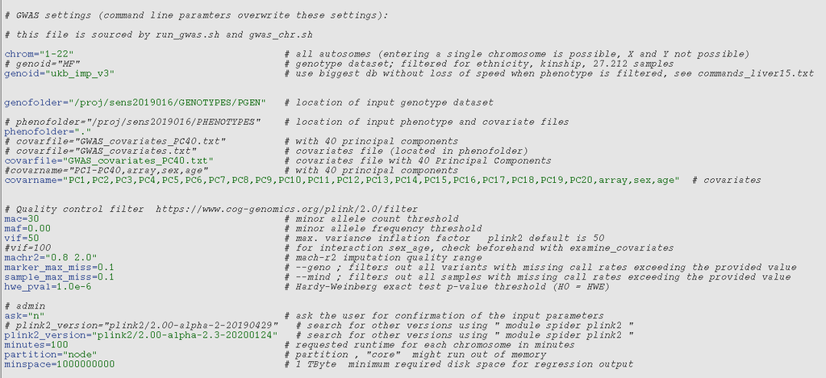

The settings file for run_gwas

Different settings files provide input parameters for different programs:

| Settings file | Programs reading that file |
| --- | --- |
| gwas_settings.sh | run_gwas.sh ; gwas_chr.sh ; run_gwas_single.sh |
| cojo_settings.sh | run_cojo.sh ; cojo_pheno ; cojo_convert.sh; cojo_chr.sh ; cojo_collect.sh ; cojo_clean.sh |
| clump_settings.sh | run_clump.sh ; clump_pheno.sh ; clump_chr.sh |
| review_settings.sh | review_gwas.sh |
| review_settings.R | review_gwas.R |
| archive_settings.sh | archive_gwas.sh ; retrieve_gwas.sh ; tar_gwas.sh ; untar_gwas.sh |
| convert_settings.sh | convert_genotype.sh ; convert_genotype_chr.sh |
| diagnose_settings.sh | gwas_diagnose.sh ; gwas_diagnose_INT.sh ;gwas_diagnose_nomarker.sh ;extract_genotype.sh |
| diagnose_settings.R | *deprecated* |
| extract_settings.sh | extract_samples.sh ; extract_samples_chr.sh ; extract_snps.sh ; extract_snps_chr.sh |
| remove_settings.sh | remove_samples.sh ; remove_samples_chr.sh |
| extract_raw_settings.sh | extract_raw.sh |
| fetch_settings.sh | fetch_pheno.sh |
| linkage_settings.sh | linkage_pair.sh |
| stats_settings.sh | get_stats.sh |

Note that the scripts are always called without the corresponding suffix because softlinks have been created, e.g.

```
ln -s run_gwas.sh run_gwas
```

As a consequence, you can just call “*run_gwas*” instead of “*run_gwas.sh*”.

Changes in the settings files can be made to adapt to your needs. However, it is important to stick to [bash syntax](https://ss64.com/bash/) in the settings files with suffix *.sh* and to R syntax in the settings files with suffix *.R*. Text following a hashtag (#) is a comment and is irrelevant for the code. Feel free to add your own comments.

# Input verification

Most of the scripts conduct a number of checks in order to make sure that the input is correct before starting the program (sending it to the SLURM).

Validation is made regarding:

- Correct format of input characters (e.g. chromosome numbers)
- Availability of input files (genotype files, phenotype files, covariate files, …)
- Availability of sufficient disk space (the minimum required disk space is defined in the associated settings file)
- Correct phenotype and covariate names (which must be column names of the phenotype or covariate files)

In case of any inconsistency, an *ERROR* message is shown containing script name and failure description.  
Moreover, the auxiliary program *check_file* can examine if a file is correctly formatted.

# GWAS pipeline

### Workflow

An overall of the workflow is shown in the scheme below. The most important part is the linear or logistic regression conducted by the script *run_gwas* (and it’s subprograms). You can traverse the pipeline along some path indicated by the red arrows. For instance, you can just run the regression and then immediately proceed to *review_gwas* in order to get a visual summary of the regression results. Alternatively, you can squeeze in GCTA-COJO or PLINK-CLUMP (or both) in order to identify markers which are in linkage equilibrium.

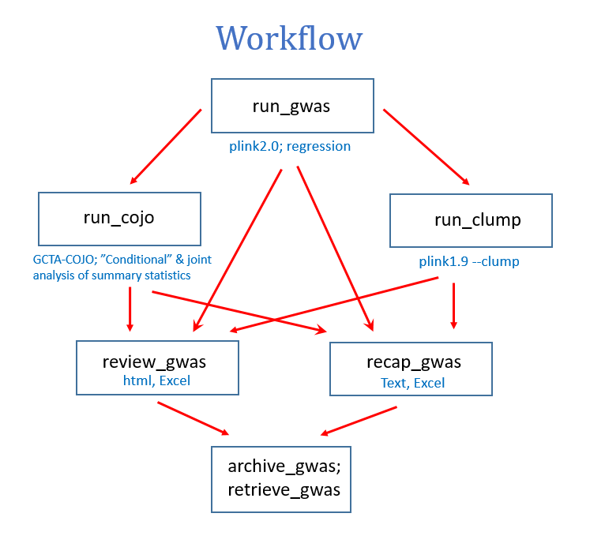

Each of the programs calls a number of sub-programs (e.g. for each phenotype and for each chhromosome), see below.

### Regression: PLINK2.0

The linear or logistic regression is conducted using [PLINK2.0](https://www.cog-genomics.org/plink/2.0/).

#### Parameters

The name of the main script running the regression is *run_gwas*, which has the following command line parameters:

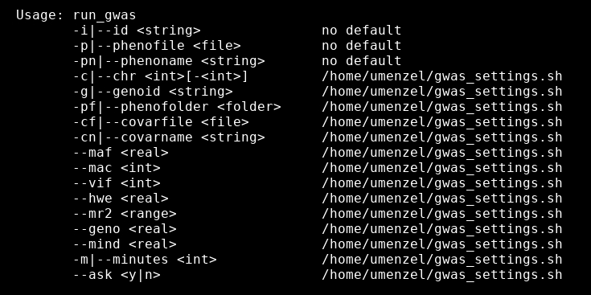

Command line options for run_gwas

The screenshot shows what you see if the program name is typed without any parameter.

| Parameter | Description | Variable name | Default value |
| --- | --- | --- | --- |
| id | job identifier | ident | none |
| phenofile | phenotype file | phenofile | none |
| phenoname | phenotype name | phenoname | none |
| phenofolder | phenotype file location | phenofolder | ~/gwas_settings.sh |
| covarfile | covariate file name | covarfile | ~/gwas_settings.sh |
| covarname | names of covariates to include | covarname | ~/gwas_settings.sh |
| genoid | genotype file identifier | genoid | ~/gwas_settings.sh |
| chr | chromosomes | chrom | ~/gwas_settings.sh |
| maf | threshold for minor allele frequency | maf | ~/gwas_settings.sh |
| mac | threshold for minor allele count | mac | ~/gwas_settings.sh |
| vif | maximum allowed variance inflation factor | vif | ~/gwas_settings.sh |
| hwe | p-value threshold for HWE test | hwe_pval | ~/gwas_settings.sh |
| mr2 | allowed MACH-r2 imputation quality range | machr2 | ~/gwas_settings.sh |
| geno | maximum missing call rate for variants | marker_max_miss | ~/gwas_settings.sh |
| mind | maximum missing call rate for samples | sample_max_miss | ~/gwas_settings.sh |
| minutes | required runtime in minutes | minutes | ~/gwas_settings.sh |
| ask | ask for confirmation before start | ask | ~/gwas_settings.sh |

The 3rd column of the table (“*Variable name*”) displays the variable names used internally in the scripts and in the settings file *~/gwas_settings.sh*.

The minimum input consists of the job identifier (“*id*”), the phenotype file (“*phenofile*”), and the phenotype names (“*phenoname*”). (As a rule, parameters without default values *must* be invoked on the command line.) Other parameters are sourced from the “settings file” *gwas_settings.sh*, but can be overwritten on the command line. Very few parameters are exclusively defined in the settings file, e.g. the PLINK2.0 version, see the table below.

The job identifier is a character string which can be freely chosen. It serves for the identification of the project and for labeling of the output files. All output files will be stored in a folder with the same name as the identifier. The folder is automatically created by the script.

The phenotype file must be in the format accepted by PLINK2.0, see the input file description. Each column - except for the first two being reserved for Individual ID (**IID**) and Family ID (**FID**)) - represents a quantitative or a binary phenotype.

The phenotype names must be column names of the phenoytype file (this is checked by the script). Multiple phenotypes can be invoked as a comma-separated list, but be aware that submitting many phenotypes at once starts many jobs in the *SLURM* simultaneously. (The number of jobs submitted is the number of phenotypes times the number of chromosomes invoked). The phenotype file must be located in the folder defined by *phenofolder*. (If a dot is entered for *phenofolder*, the phenotype file must reside in the current folder, i.e. the folder the *run_gwas* is started from.)

The file containing the covariates (“*covarfile*”) must be in the format required by PLINK2.0, see the input file description. Again, the first two columns must contain **IID** and **FID**, while all other columns represent a quantitative or a binary covariate. The names of the covariates to be included must be column names of the covariate file (also checked by the script). The covariate file must be located in the same folder as the phenotype file (i.e. it must be located in the current folder if a dot was entered for the *phenofolder* variable).

The *genoid* parameter specifies which genotype dataset is used as input. Only a few choices are possible, depending on the project you are working with. In general, it should be sufficient to keep the definition which is pre-selected in *gwas_settings.sh*.

The script runs the regression on all chromosomes invoked for each phenotype simultaneously, if the necessary number of computing nodes is available. By default, all autosomes are included in the analysis (defined in *~/gwas_settings.sh*). By changing the the *chr* parameter, a single chromosome or a (contiguous) range of chromosomes can also be analysed (e.g. 1-10 for the first 10 chromosomes). Up to now, only autosomes can be included in the regression (but this can be changed easily)

Samples with a minor allele frequency below the threshold “*maf*” are discarded from the association study, likewise samples with a minor allele count below the threshold “*mac*”. Note that too low values of *maf* or *mac* can make the regression results unreliable. See also the PLINK manual regarding [filtering](https://www.cog-genomics.org/plink/1.9/filter#maf). Minor allele frequency and minor allele count are calculated based on the portion of samples included in the actual regression. This portion is the intersection of:

- samples included in the genotype file,
- samples included in the phenotype file, and
- samples included in the covariate file.

This implies that it is sufficient to filter one of these files, if filtering is intended. For more information regarding filtering, check out the scripts filter_samples, filter_pheno, or filter_phenotype.

PLINK checks for Hardy-Weinberg equilibrium of the allele frequencies using the [Hardy-Weinberg Exact Test](https://www.cog-genomics.org/plink/2.0/filter#hwe). The $p$-value threshold (“hwe”) is set to $p = 1.0\cdot 10^{-6}$ by default (*~/gwas_settings.sh*). The null hypothesis states that the allele frequencies are in Hardy-Weinberg equilibrium. Consequently, low $p$-values indicate a statistical significant deviation from the equilibrium, and the corresponding markers are excluded from the analysis.

The *mr2* parameter tells PLINK the accepted [imputation quality range](https://www.cog-genomics.org/plink/2.0/filter#mach_r2_filter) which is set to $0.8-2.0$ by default. Imputation has been conducted using the [MaCH software package](https://onlinelibrary.wiley.com/doi/full/10.1002/gepi.20533).

The *geno* parameter filters out markers with missing-call rates exceeding the provided value, see the [PLINK manual](https://www.cog-genomics.org/plink/2.0/filter#missing). In a similar manner, the *mind* paramter filters out samples with missing-call rates above the defined threshold. Both thresholds are set to $0.1$. Note that the corresponding variable names (used in the script and in *~/gwas_settings.sh*)  
are *marker_max_miss* and *sample_max_miss*, respectively, as documented in the table above.

The *minutes* parameter specifies the requested runtime in minutes for each chromosome. If enough nodes are available, this is the approximate runtime of the whole job, because the chromosomes are run simultaneously. Too low values can lead to premature interruption of the regression, leading to unfinished output files (summary statistics). Therefore, it is important to check the logfiles for errors and warnings, as described below.

The *ask* parameter can be set to “y” or “n”. When set to “y”, the user is asked to confirm the invoked settings before the job is sent to the SLURM.

As already mentioned, a few parameters can only be set by editing the *~/gwas_settings.sh*:

| Parameter | Desription | Variable name | Default value |
| --- | --- | --- | --- |
| plink_version | PLINK program version | plink_version | plink2/2.00-alpha-2.3-20200124 |
| partition | partition (node or core) | partition | node |
| minspace | miniumum required disk space | minspace | 1.000.000.000 kB = 1 TB |

The parameter *plink_version* specifies the release of PLINK2.0 used for the calculation. New plink versions can be downloaded [here](https://www.cog-genomics.org/plink/2.0/). The *plink_version* parameter must then be modified accordingly.

The program checks how much disk space is available in the current file system before starting the job, and compares it with the value defined for *minspace*. The job terminates with an error message if the available disk space is below the defined limit. The actual value declared in the settings file (1 Terabyte) is quite generous. However, the limit should not be chosen too low because filling up the disk to the last byte can cause quite a lot of trouble.

#### Input files

Three types of files must be available before a **GWAS** can be started:

- genotype files
- phenotype files, and
- covariate files.

The genotype files have been prepared and are localized in the folder */proj/sens2019016/GENOTYPES* and */proj/sens2019570/GENOTYPES*, respectively. These folders have two subfolders *BED* and *PGEN*, containing genotype files in different formats:

- binary genotype format (*.pgen*), see [here](https://www.cog-genomics.org/plink/2.0/formats#pgen)
- binary biallelic format (*.bed*), see [here](https://www.cog-genomics.org/plink/2.0/formats#bed)

Two different genotype file formats must be provided because different programs of the pipeline require different formats. The *run_gwas* script uses the *pgen* files only.

The phenotype file names are declared with the parameter *phenofile*, see above. Phenotype files must be in the format requested by PLINK2.0, see the corresponding [description](https://www.cog-genomics.org/plink/2.0/input#pheno). In general, these files must at least have a column containing the Individual ID (“IID”). In the pipeline presented here, the Family ID (“FID”) column is also mandatory.

A typical phenotype file with one quantitative trait looks like this (first 10 lines):

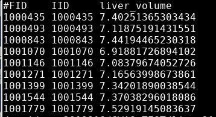

A phenotype file

Every column of the phenotype file (except for the first two) stands for a phenotype. The column names in the phenotype file must agree with the parameter invoked for *phenoname*. Multiple phenonames can be entered as a comma-separated list.

It is important to note that binary phenotypes are expected to be encoded with particular integer numbers (1=control, 2=case, see this [site](https://www.cog-genomics.org/plink/2.0/input#pheno)). Missing values must be encoded with 0 or -9 (negative 9).

If the input format is correct, the script detects automatically if a trait is quantitative or binary, and conducts a linear or logistic regression accordingly. Quantitative and binary phenotypes can be combined in a single run of the pipeline.

The covariate files must have a similar structure. There is a prepared covariate file (“*GWAS_covariates_PC40.txt*”) available, containing 45 covariates (age, age_squared, sex, array, height as well as 40 principal components created by PCA with regard to genetic relationship of the samples). The file contains 337,466 samples (filtered for Caucasian ethnic background and absence of relatives in the database).

The columns of both the phenotype file and covariate file must be tab-separated. Input files for PLINK can be checked for accuracy before starting the pipeline using the script *check_file*, see the section Auxiliary scripts.

#### Output files

The script *run_gwas* creates a number of output files [in the table, a star (*) stands for a string that depends on the chosen input parameters]:

| File name pattern | Description |
| --- | --- |
| *.glm.linear | summary statistics after linear regression, for each chromosome |
| *.glm.logistic | summary statistics after logistic regression, for each chromosome |
| *_gwas.log | main logfile |
| *_gwas_chrom*.log | chromosome-specific logfile |
| *_gwas_signif.txt | text file containing all genome-wide significant markers |
| *_gwas_params.txt | parameter file |
| *.Rdata | binary data files storing regression results, to be used in subsequent scripts |

The summary statistics files contain the results of the linear or logistic regression, including the slopes of the regression lines ($\beta$), $p$-values, standard errors, as well as effect and alternate alleles and their corresponding frequencies.

The “parameter file” contains the parameters chosen on command line or read from the settings file. This information can be used to reproduce the pipeline run. The file is especially important because the information therein is also used by subsequent scripts in the pipeline.

As mentioned above, all output files created in a single run of the pipeline are stored in a separate folder, having the same name as the job identifier chosen. The *gwas_settings.sh*, the covariate file and the phenotype file are also copied to this folder, in order to make the pipeline run reproducible.

If only genome-wide significant markers are needed (e.g. for Mendelian Randomization), the results obtained so far should be sufficient. The scripts *merge_gwas_results* or *concat_gwas_results* can be used to concatenate the regression results obtained for the individual chromosomes, see the section “Auxiliary scripts”. If the regression results must be inspected in detail, the script *review_gwas* can be run, see the corresponding description.

The logfiles combine information created by *run_gwas* (or it’s sub-programs) with the complete logfile created by PLINK2.0.

#### Checking accuracy

It is recommended to check if the regression step was executed without failure before proceeding with the next steps of the pipeline. Therefore, it is useful to search all logfiles in the results-folder for errors or warnings by using the following Linux commands:

```
fgrep -i error *.log
fgrep -i warning *.log
```

The *-i* option stands for *ignore case*, ensuring that also phrases like “*ERROR*” or “*Error*” are detected. If these commands yield no output, the regression step was most likely successful.

A frequently occuring “error” is exceedance of the requested runtime. In that case, the job can be restarted with a higher runtime claim (increased *minutes*-parameter).

It is also possible to repeat the regression for a single chromosome using the script *run_gwas_single*. This should be preferred over conducting *run_gwas* for that chromosome, because it can be started in the existing results-folder, and adds the results to the existing ones, while *run_gwas*, performed for a single or a few chromosomes, creates a new folder to store the results.

If a more rigorous validation is intended, the script *check_gwas* can be executed, see here for details.  
This program also checks if the results are complete, so that aborted jobs can be identified. Additionally, the script considers the dates of the logfiles, in order to exclude obsolete files.

#### Subprograms

The script *run_gwas* calls the script *gwas_chr* which performes the regression step for a single chromosome and for all phenotypes entered.  
The individiual chromosomes are sent to the SLURM simultaneously if enough resources are available.

#### Examples

The following exemplary command provides the minimal set of command line parameters that have to be entered:

```
run_gwas --id Test --phenofile liver_fat.txt  --phenoname liver1
```

All other program parameters are taken from *~/gwas_settings.sh*.

When launched as shown in the example, the *run_gwas* script automatically creates s folder names “*Test*” in the current directory. All output of the pipeline is then stored in this folder. The file “liver_fat.txt” must reside in the location declared by the parameter *phenofolder*. This file must have a column named “*liver1*” (in addition to the “#FID” and “IID” columns).

It is also possible to use the short version of the formal parameters, so that

```
run_gwas -i Test  -p liver_fat.txt  -pn liver1
```

would submit exactly the same job.

Often, jobs terminate halfway because the runtime limit was exceeded. In that case, the job can be restarted with a modified runtime claim:

```
run_gwas --id Test1  --phenofile liver_fat.txt  --phenoname liver1 --minutes 180
```

which would request 3 hours runtime for each chromosome.

Note that you have to choose another identifier (*- -id* ) if the job is restarted. Otherwise, *run_gwas* exits with an error message in order to prevent removal of finished GWAS runs by accident. If you are sure that a GWAS run is obsolete, you can remove the existing folder with

```
rm -r Test
```

In general, be careful with the *rm* command, there is no such thing like a bin in UNIX/Linux. Once a file or directory is removed, it cannot be recovered if no backup is available. Check the UPPMAX [website](https://www.uppmax.uu.se/support/faq/resources-faq/backup-at-uppmax/) to see how the backup is organized.

If many covariate names are to be entered on the command line (overwriting the declarations in *~/gwas_settings.sh*), it is convenient to define a variable which stores the name string:

[output not shown]

The token “$cov” in the command is replaced by the complete string defined by the upper command. The command above sets also the cutoff for the $p$-value calculated by the Hardy-Weinberg Test to $1.0 \cdot 10^{-20}$.

### Linkage: GCTA-COJO

The GCTA-COJO program identifies markers in linkage equilibrium (“independent markers”) by analysing the summary statistics file (*.linear and *.logistic, respectively) generated by *run_gwas*. A description of the method can be found in this [article](https://www.ncbi.nlm.nih.gov/pmc/articles/PMC3593158/). A detailed description of the software was given in this [paper](https://www.ncbi.nlm.nih.gov/pmc/articles/PMC3014363/). The corresponding website is [here](https://cnsgenomics.com/software/gcta/#COJO).

#### Parameters

The main script conducting GCTA-COJO is *run_cojo*. In order to run the program, you must change to the directory created by *run_gwas*. If the identifier was chosen to be “Test”, as in the example above, this is accomplished by typing

```
cd Test
```

The program *run_cojo* has the following command line parameters:

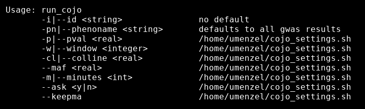

run_cojo parameters

| Parameter | Description | Variable name | Default value |
| --- | --- | --- | --- |
| id | job identifier | ident | none |
| phenoname | phenotype name | phenoname | all phenotypes run |
| pval | p-value cutoff for genome-wide significance | pval | ~/cojo_settings.sh |
| window | window for assumed linkage equilibrium | window | ~/cojo_settings.sh |
| colline | cutoff for collinearity ($R^2$) | collinearity | ~/cojo_settings.sh |
| maf | threshold for minor allele frequency | maf | ~/cojo_settings.sh |
| minutes | required runtime in minutes | minutes | ~/cojo_settings.sh |
| ask | ask for confirmation before start | ask | ~/cojo_settings.sh |
| keepma | keep cojo input file | keepma | ~/cojo_settings.sh |

The job identifier ( *id* ) has to be the one used in *run_gwas*. It is checked by the script if the actual folder name agrees with this identifier. If no phenotype name ( *phenoname* ) is entered on the command line, all phenotypes run through the regression by *run_gwas* will be considered. (The phenotype names are then taken from the parameter file described above.)

For the $p$-value defining genome-wide significance of a marker ( *pval* ), a default of $5.0 \cdot 10^{-8}$ is most frequently used. That corresponds to a Bonferroni adjustment for multiple testing for one million markers.

The parameter *window* tells the program at what distance (in Kb) a pair of markers is considered to be in complete linkage equilibrium. The default value is 5000, if not changed in *~/cojo_settings.sh*.

The *colline* parameter controls how stringent collinearity between candidate markers is punished. A marker is excluded if the $R^2$ calculated by multiple regression against the already chosen markers is bigger than the chosen value. This is also explained [here](https://cnsgenomics.com/software/gcta/#COJO). By default, the parameter is set to 0.9.

By choosing the *maf* parameter, SNP’s with a minor allele frequency lower than that value are excluded from the results. Often, this filtering is already performed in the regression step, see above.

The *minutes* parameter specifies the requested runtime per chromosome.

The *ask* parameter can only be set to “y” or “n”. When set to “y”, the user will be asked to confirm the chosen settings before the jobs are sent to the queue. The default value is “y” (declared in *~/cojo_settings.sh*) because the number of jobs to submit might be very large, see below.

The parameter *keepma* tells the script to keep the input file for *run_cojo* after the program has been running, instead of deleting it. This file is constructed on the basis of the GWAS output files (and has the suffix *.ma* ). Keeping that file is mainly important for debugging. By default, the option is set to “n” because the file is quite big (about 500 MB).

A few parameters cannot be changed on the command line but only by editing the *~/cojo_settings.sh* file:

| Parameter | Desription | Variable name | Default value |
| --- | --- | --- | --- |
| skip_chrom | skip chromosomes without significant SNP’s | same | 1 |
| sleep_between_pheno | pause submission to SLURM | same | 0 |
| partition | requested partition (node or core) | same | node |
| minspace | miniumum required free disk space | same | 100.000.000 kB = 100 GB |
| cojo_convert_time | required runtine for cojo_convert.sh | same | 20 minutes |
| cojo_collect_time | required runtine for cojo_collect.sh | same | 10 minutes |
| cojo_clean_time | required runtine for cojo_clean.sh | same | 10 minutes |
| alt_genoid | genotype identifier for run_cojo | same | FTD_rand |

The option *skip_chrom* tells the program that chromosomes having no significant hit or just one significant hit after regression are excluded from the analysis. ( As a matter of course, if the chromosome has just one significant hit, this is the independent one! ) The chromosome is also excluded if no or only one hit remains after *maf*-filtering (in case that option was chosen). If such a situation occurs, the user receives a message like that:

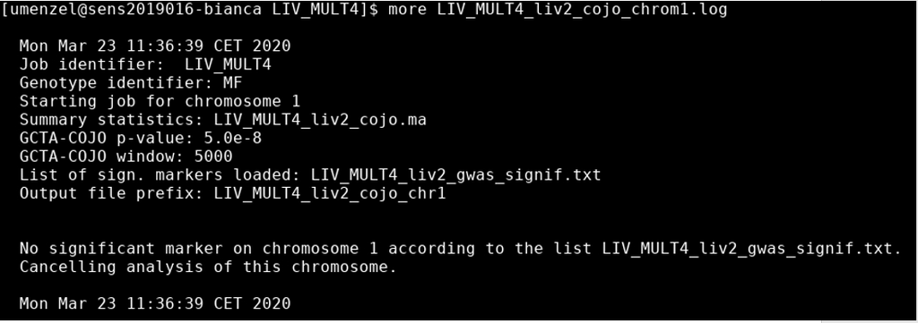

or like that:

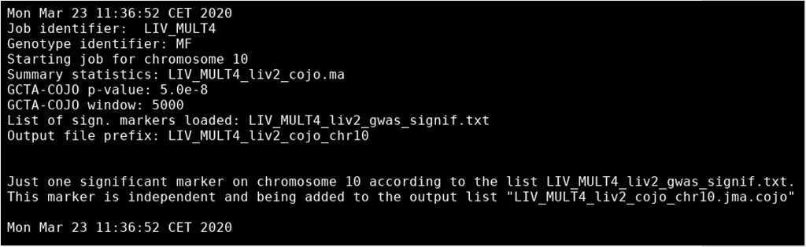

When *sleep_between_pheno* is set to a non-zero value, the script pauses submission to the queue that many minutes between individual phenotypes (if multiple phenotypes were chosen). This option can be used to prevent overloading of the queue (*run_cojo* submits 25 jobs per phenotype, see below.

The *partition* parameter can either be “node” or “core”. Most of the time, “node” is a better choice because considerably more CPU memory is provided when this option is chosen. For more information look [here](https://www.uppmax.uu.se/support/user-guides/slurm-user-guide/#tocjump_1777731700127163_5).

The program checks how much disk space is available in the current file system before starting the job, and compares it with the value defined for *minspace*. It stops with an error message if the disk space is below the defined limit. The actual value declared in the settings file (100 GB) is quite generous. However, the limit should not be chosen too low because filling the disk up to the last byte can cause quite a lot of trouble.

The parameters *cojo_convert_time*, *cojo_collect_time*, and *cojo_clean_time* declare runtime requests for some subprograms called by *run_cojo*. For details, see the sub-program section. These are relatively small programs so that the defaults shown in the table above should be sufficient.

#### Input files

No input files have to be declared for *run_cojo*. The script reads the output files created during the regression step and converts them to the appropiate input format for *run_cojo*. Other necessary information is taken from the parameter file. However, it is important to start the script in the folder containing the GWAS output.

#### Output files

The script *run_cojo* creates the following output files [a star (*) stands for a string which depends on input parameters]:

| File name pattern | Description |
| --- | --- |
| *_cojo.log | main logfile for a phenotype |
| *_cojo_chrom*.log | chromosome-specific logfile |
| *_cojo_clean.log | logfile for cojo_clean.sh |
| *_cojo_collect.log | logfile for cojo_collect.sh |
| *_cojo_convert.log | logfile for cojo_convert.sh |
| *_cojo.jma | list of independent markers for a phenotype |
| *_cojoed_markers.RData | binary data file storing independent markers for a phenotype |
| *_cojoed_orig_markers.RData | the same with original $\beta$ and $p$-values |
| *_cojo_files.tar.gz | some archived output files of minor importance |

The main results, containing the independent markers, are stored in the file ending on "*_cojo.jma". The *.RData files contain information for subsequent scripts.

GCTA-COJO adds further information to the parameter file created in the regression step.

#### Checking accuracy

Again, it is recommended to check if all parts of the pipeline were executed without failure so far before proceeding with the next steps. Therefore, it is useful to parse all logfiles in the results-folder for errors or warnings. This can be accomplished by using the following Linux commands:

```
fgrep -i error *.log
fgrep -i warning *.log
```

The *-i* option stands for *ignore case*, ensuring that also phrases like “*ERROR*” or “*Error*” are detected. If these commands yield no output, the regression step was most likely successful. If exactly launched as displayed above, the command checks the logfiles created in the regression step, too.

A frequently occuring error is runtime limit exceedance, especially for the chromosomes harboring many markers (e.g. chromosome 2). In that case, the job must be restarted with a higher runtime claim, by scaling up the *minutes*-parameter.

If a more rigorous check is to be done, the script *check_gwas* can be executed, see some details here. This program checks also completeness of the results and considers the dates of the logfiles in order to exclude outdated files.

#### Subprograms

The script *run_cojo* calls *cojo_pheno*, *cojo_convert*, *cojo_chr*, *cojo_collect*, and *cojo_clean* as shown in the graph:

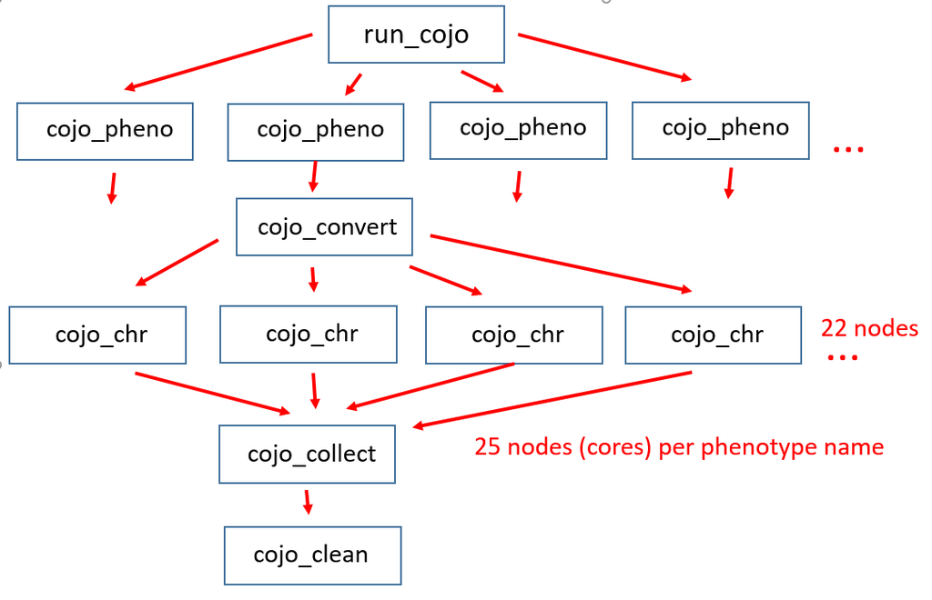

The sub-program *cojo_convert* reformats the output of *run_gwas* to serve as input for *run_cojo*. The *cojo_pheno* starts the jobs for a single phenotype, calling *cojo_chr* for all invoked chromosomes. *cojo_collect* mainly combines the results for the individual chromsomes, while *cojo_clean* collects warnings and errors from all logfiles created, deletes some temporary files and archives files with minor importance in order to save disk space.

Note that 25 jobs for each phenotype are submitted if all autosomes are analyzed. Using the *sleep_between_pheno* option can unburden the server, because the submission is paused between the individual phenotypes, so that “only” 25 jobs are started at a time.

The individual sub-programs started by *run_cojo* have several dependencies. The script *cojo_convert* has to be finished before other sub-programs can be started, because *cojo_convert* provides the input files for the whole chain. Furthermore, *cojo_collect* and *cojo_clean* can only be started at the end of the chain. Consequently, if you list your jobs running the *squeue* command, you’ll notice that not all jobs can be started simultaneously:

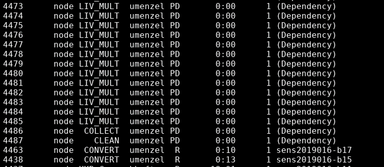

As shown in the plot, the *cojo_convert*, labelled *CONVERT*, has already started (as indicated by the letter **R**) while all other sub-programs are flagged with “*Dependency*”.

#### Examples

In order to run *GCTA-COJO*, you have to change to the folder containing the regression results. If the identifier was chosen to be “Test” in the regression step, this can be accomplished by typing

```
cd Test
```

The minimal input of *run_cojo* could for instance be:

```
run_cojo --id Test
```

In that case, all phenotypes are treated that have been run through the regression step (data is taken from the parameter file).

In case you are interested in a subset of the phenotypes that have been running through regression, you can explicitly make a request for these phenotypes:

```
run_cojo --id Test --phenoname liver_fat,liver_size
```

This command includes two phenotypes only (but still uses 50 nodes or cores on the server!).

Unfortunately, it will often be necessary to repeat the run with increased runtime request, because the job could not be finished timely. The runtime limit can be adjusted by modifying the *minutes* parameter:

```
run_cojo --id Test --phenoname liver_fat,liver_size --minutes 200
```

Please keep in mind that you can also use the short version of the formal parameters, so that the last command can be replaced by:

```
run_cojo -i Test -pn liver_fat,liver_size -m 200
```

The *minutes* parameter refers to the runtime for a chromosome.

There are more arguments which can be supplied to *run_cojo*, see the table above. Just type *run_cojo* without any argument in order to obtain a complete list of options. Also, keep in mind that the default options can be changed by modifying the file *~/cojo_settings.sh*.

### Linkage: PLINK-CLUMP

An alternative approach to identify SNPs in linkage equilibrium (“independent markers”) is **clumping**, performed by PLINK1.9. Clumping starts with markers having $p$-values (from regression) below a user-defined threshold (called “**index SNPs**”) and creates clumps of all other markers that

- are located within a certain window around the index SNP, and
- are in linkage disequilibrium with the index SNP.

The linkage disequilibrium is evaluated based on an $R^2$-threshold. More details can be found [here](http://zzz.bwh.harvard.edu/plink/clump.shtml), some additional information is [here](https://www.cog-genomics.org/plink/1.9/postproc). The basic PLINK article is by [Purcell et al.](https://www.ncbi.nlm.nih.gov/pmc/articles/PMC1950838/).

#### Parameters

The main script running this algorithm is *run_clump* which has to be started inside the folder containing the regression results. If the identifier was chosen to be “Test” in the regression step, the following command changes to the appropiate folder:

```
cd Test
```

The program *run_clump* has the following command line parameters:

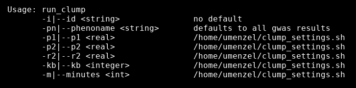

run_clump parameters

| Parameter | Description | Variable name | Default value |
| --- | --- | --- | --- |
| id | job identifier | ident | none |
| phenoname | phenotype names | phenoname | all phenotypes run |
| p1 | $p$-value cutoff for genome-wide significance | clump_p1 | ~/clump_settings.sh |
| p2 | secondary significance threshold | clump_p1 | ~/clump_settings.sh |
| r2 | threshold for $R^2$ in LD calculation | clump_r2 | ~/clump_settings.sh |
| kb | window for assumed linkage equilibrium | clump_kb | ~/clump_settings.sh |
| minutes | requested runtime in minutes | minutes | ~/clump_settings.sh |

The job identifier ( *id* ) has to be the same as used in *run_gwas*. It is checked if the actual folder name agrees with this identifier. If no phenotype name ( *phenoname* ) is entered on the command line, all phenotypes run through the regression by *run_gwas* will be considered (The phenotype names are then taken from the parameter file described above.)

The parameter *p1* denotes the threshold for genome-wide significance, thus defining potential index SNPs. The default value is $5.0 \cdot 10^{-8}$. The parameter *p2* denotes the secondary significance threshold, with a default value of $5.0 \cdot 10^{-6}$. Markers within a clump will be explicitly listed in the output if their $p$-value is below the *p2*-threshold.

The [coefficient of determination](https://en.wikipedia.org/wiki/Coefficient_of_determination) (“variance explained”, $R^2$, parameter *r2* ) is used as a measure for the linkage of a pair of markers. Two markers are considered to be in linkage disequilibrium if the corresponding *r2* is above the defined value. If two markers have a distance (in kilobases) bigger than the *kb* parameter, they are a priori considered to be in linkage equilibrium.

The following parameters cannot be changed on the command line but only by editing *~/clump_settings.sh* :

| Parameter | Desription | Variable name | Default value |
| --- | --- | --- | --- |
| genofolder | location of the genotype files | same | /proj/sens2019016/GENOTYPES/BED |
| sleep_between_pheno | pause submission to queue | same | 0 |
| partition | requested partition (node or core) | same | node |
| minspace | miniumum required free disk space | same | 100.000.000 kB = 100 GB |
| plink_version | plink 1.9 version used | same | plink/1.90b4.9 |
| clump_collect_time | requested runtine for clump_collect.sh | same | 10 minutes |
| alt_genoid | alternative genotype identifier | same | FTD_rand |

The *genofolder* parameter determines the location of the genotype data. Because PLINK-CLUMP can only be used with PLINK version 1.9, the genotype data must have *binary biallelic genotype* [format](https://www.cog-genomics.org/plink/1.9/formats#bed) (including .bed; .bim; .fam files).

When *sleep_between_pheno* is set to a non-zero value, the script pauses submission to the queue that many minutes between individual phenotypes (if multiple phenotypes were chosen). This option can be used to prevent overloading of the server queue (*run_clump* submits 23 jobs per phenotype, see below).

The *partition* parameter can either be “node” or “core”. Most of the time, “node” is a better choice because considerably more CPU memory is provided when this option is chosen. For more information regarding memory management look [here](https://www.uppmax.uu.se/support/user-guides/slurm-user-guide/#tocjump_1777731700127163_5).

The program checks how much disk space is available in the current file system before starting the clump program, and compares it with the value defined for *minspace*. It stops with an error message if the disk space is below the defined limit. The actual value declared in the settings file *~/clump_settings.sh* (100 GB) is quite generous. However, the limit should not be chosen too low because filling the disk up to the last byte can cause quite a lot of trouble.

The parameter *plink_version* specifies the release of PLINK1.9 used for the calculation. New PLINK versions can be downloaded [here](https://www.cog-genomics.org/plink/). The *plink_version* parameter must then be modified accordingly. Keep in mind that clumping can only be performed using (the older) [PLINK1.9](https://www.cog-genomics.org/plink/).

The parameter *clump_collect_time* declares the requested runtime for the subprogram *clump_collect.sh*. This is a relatively small program so that the default shown in the table above should be sufficient.

In order to shorten runtime, *run_clump* can use a subset of the available genotype data as a reference sample.  
This is determined by the parameter *alt_genoid* (“alternative genotype identifier”).  
In *~/clump_settings.sh*, the default is set to *FTD_rand*, which refers to 10,000 individuals randomly chosen from a genotype dataset that was filtered for Caucasian ethnic background and for absence of relatives in the dataset. Note that *FTD_rand* does not contain all samples (individuals) but all variants in order to enable LD calculation. When the *alt_genoid* entry in *~/clump_settings.sh* is outcommented, *run_clump* uses the same genotype dataset as used in the regression step. (This genotype dataset is inferred from the parameter file created in the regression step, see above. ) Additional information regarding the reference dataset can be found on the [plink1.9 website](http://zzz.bwh.harvard.edu/plink/clump.shtml).

#### Input files

No input files have to be declared for *run_clump*. The script reads the output files created during the regression step and converts them to the appropiate input format for *run_clump*. Other necessary information is taken from the parameter file. However, as already mentionend, it is important to start the script in the folder containing the GWAS output files (“*.linear” or "*.logistic").

#### Output files

The script *run_clump* creates the following output files [a star (*) stands for a string which depends on input parameters]:

| File name pattern | Description |
| --- | --- |
| *_clump.log | main logfile for a phenotype |
| *_clump_chrom*.log | chromosome-specific logfile |
| *_clump_collect.log | logfile for clump_collect.sh |
| *_clump.jma | list of independent markers for a phenotype |

The main results, containing the independent markers, are stored in a file ending on "*_clump.jma". (The suffix *.jma* is chosen to harmonize with the main GCTA-COJO output.)

PLINK_CLUMP adds further information to the parameter file created in the regression step.

#### Checking accuracy

Again, it is recommended to check if all parts of the pipeline were executed without failure so far before proceeding with the next steps. Therefore, it is useful to parse all logfiles in the results-folder for errors or warnings. This can be accomplished by using the following Linux commands:

```
fgrep -i error *.log
fgrep -i warning *.log
```

The *-i* option stands for *ignore case*, ensuring that also phrases like “*ERROR*” or “*Error*” are detected. If these commands yield no output, the regression step was most likely successful. If exactly launched as displayed above, the command also checks the logfiles created in the regression step and in the GCTA-COJO step (if conducted).

The following warning can be ignored: “*No significant - -clump results. Skipping*”. It means that the corresponding chromosome didn’t harbor any genome-wide significant hit.

A frequently occuring error is runtime limit exceedance, especially for the chromosomes harboring many markers (e.g. chromosome 2). In that case, the job must be restarted with a higher runtime claim, by scaling up the *minutes*-parameter.

If a more rigorous check is to be done, the script *check_gwas* can be executed, see some details here. This program checks also completeness of the results and considers the dates of the logfiles in order to exclude outdated files.

#### Subprograms

The script *run_clump* calls the subprograms *clump_pheno*, *clump_chr* , and *clump_collect* as shown in the graph:

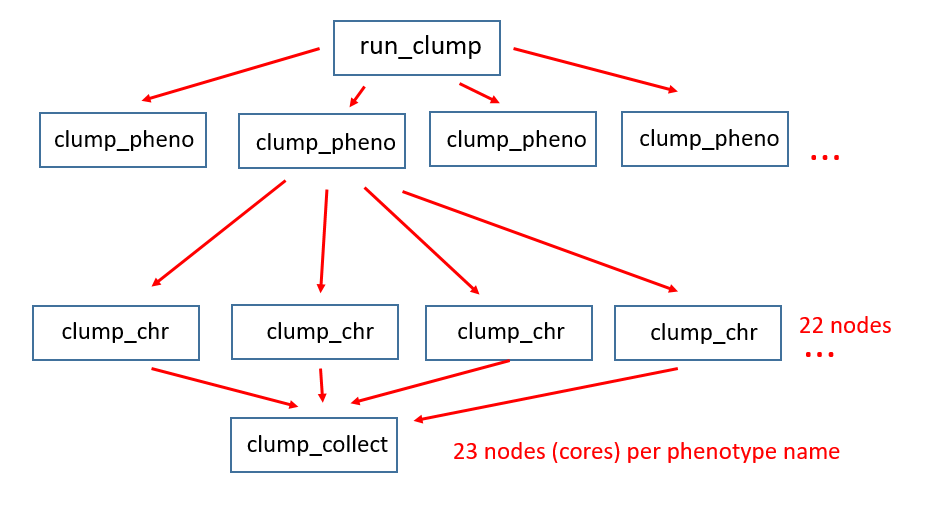

The script *clump_pheno* starts the jobs for a single phenotype, calling *clump_chr* for all chromosomes to be considered. *clump_chr* is the script that calls the PLINK program. The subprogram *clump_collect* combines the results for the individual chromsomes.

Note that 23 jobs for each phenotype are submitted if all autosomes are analyzed. Using the *sleep_between_pheno* option can unburden the server, because the submission is paused between the individual phenotypes, so that “only” 23 jobs are started at a time.

While the PLINK program is started simultaneously for the individual chromosomes (if enough nodes are available), the sub-program *clump_collect* must wait until all chromosomes are finished. If you list your jobs running the *squeue* command, you will therefore notice that *clump_collect* is pending :

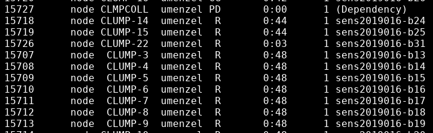

As shown in the plot, the *clump_collect* script, labelled “CLMOCOLL”, is flagged with “*Dependency*” while the PLINK jobs on the individual chromsomes (“CLUMP-XX”) are already running, as indicated by the letter **R**.

#### Examples

In order to run *PLINK-CLUMP*, you have to change to the folder containing the regression results. If the identifier was chosen to be “Test” in the regression step, this can be accomplished by typing

```
cd Test
```

The minimal input of *run_clump* may then be the following:

```
run_clump --id Test
```

In that case, all phenotypes that have been run through the regression step are treated (data is taken from the parameter file).

In case you are interested in a subset of the phenotypes that have been running through regression, you can explicitly make a request for these phenotypes:

```
run_clump --id Test --phenoname liver_fat,liver_size
```

This command includes two phenotypes only (but still uses 46 nodes or cores on the server!).

Unfortunately, it will often be necessary to repeat the run with increased runtime request, because the job could not be finished timely. The runtime limit can be adjusted by modifying the *minutes* parameter:

```
run_clump --id Test --phenoname liver_fat,liver_size --minutes 200
```

Please keep in mind that you can also use the short version of the formal parameters, so that the last command can be replaced by:

```
run_clump -i Test -pn liver_fat,liver_size -m 200
```

The *minutes* parameter refers to the runtime per chromosome (but chromosomes are running parallel if enough nodes are available).

There are more command-line arguments which can be supplied to *run_clump*, see the table above. Just type *run_clump* without any argument in order to obtain a complete list of options. Also, keep in mind that the default options can be changed by modifying the file *~/clump_settings.sh*.

### Reviewing the results

The script *review_gwas* provides a graphical summary (in HTML format) of the results obtained. It can be run immediately after *run_gwas*, or include the results of *run_cojo* and/or *run_clump*, see the workflow above. The output of *review_gwas* includes:

- a short description of the regression model,
- lists of all parameters used during the pipeline,
- statistics regarding filtering of samples and variants,
- tables of significant and/or independent variants (for PLINK-CLUMP and GCTA-COJO, if run),
- a [QQ-plot](https://en.wikipedia.org/wiki/Q%E2%80%93Q_plot) for the $p$-values originating from regression,
- a [Manhattan plot](https://en.wikipedia.org/wiki/Manhattan_plot) highlighting the genome-wide significant markers,
- a SNP density plot,
- a histogram and a Kernel density plot of the slopes for the regression lines ($\beta$-values),
- a list of the [variance inflation factors](https://en.wikipedia.org/wiki/Variance_inflation_factor) for the covariates,
- an analysis of the residuals (histogram over residuals, QQ-Plot for residuals, etc.)

#### Parameters

In order to run the program, one must change to the directory created by *run_gwas*. If the identifier was chosen to be “Test”, this is accomplished by typing

```
cd Test
```

The program *review_gwas* has the following command line parameters:

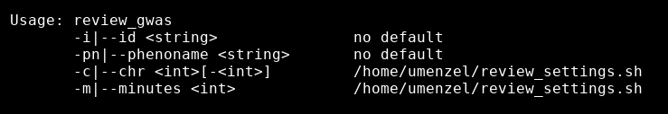

review_gwas parameters

| Parameter | Description | Variable name | Default value |
| --- | --- | --- | --- |
| id | job identifier | ident | none |
| phenoname | phenotype name | phenoname | none |
| chr | chromosomes to invoke | chrom | ~/review_settings.sh |
| minutes | required runtime in minutes | minutes | ~/review_settings.sh |

The job identifier ( *id* ) has to be the same as used in *run_gwas*. It is checked by the script if the actual folder name agrees with this identifier. The script can only handle one phenotype at a time, hence *phenoname* must be a single word. The parameter *chr* denotes the chromosomes to include, the default setting includes all autosomes (1-22), see the settings file for this script (*~/review_settings.sh*). The *minutes* parameter specifies the requested runtime for the whole script.

A few parameters cannot be changed on the command line but only by making modifications in the *~/review_settings.sh* file:

| Parameter | Desription | Variable name | Default value |
| --- | --- | --- | --- |
| minspace | miniumum required free disk space (Kb) | same | 10.000.000 = 10 GB |
| partition | requested partition (node or core) | same | node |

The program checks how much disk space is available in the current file system before starting *review_gwas*, and compares it with the value defined for *minspace*. It stops with an error message if the disk space is below the defined limit. The actual value declared in the settings file (10 GB) should be sufficient.

The *partition* parameter can either be “node” or “core”. Most of the time, “node” is a better choice because considerably more CPU memory is provided when this option is chosen. For more information regarding technical information look [here](https://www.uppmax.uu.se/support/user-guides/slurm-user-guide/#tocjump_1777731700127163_5).

The scripts *review_gwas* calls a subprogram *review_gwas.R*. This subprogram reads it’s own settings file *~/review_settings.R*, also containing some default parameter values:

| Parameter | Desription | Variable | Default value |
| --- | --- | --- | --- |
| p_threshold | $p$-value threshold (Manhattan plot | same | 5e-8 |
| bandwidth | bandwidth for kernel density plot | same | 0.01 |
| annotation | FTO and GNAT2 annotation in Manhattan plot | same | FALSE |
| colvec | Manhattan plot colors | same | c(“red”,“limegreen”) |
| max_xls | max. number of hits listed in spreadsheet | same | 500 |

Markers with a low $p$-value are emphasized in the Manhattan plot. The variable *p_threshold* defines the threshold for the $p$-values. If *annotation* is set to “TRUE”, two genes (FTO and GNAT2) are highlighted in the Manhattan plot. The *colvec* parameters determine the colors used for the Manhattan plot.

The *bandwith*-option determines how smoothly the Kernel density plot for the $\beta$-values is drawn-out. The *review_gwas* script creates a spreadsheet containing all significant markers if their number is below the *max_xls* cutoff.

When *review_gwas* running, the job is labelled with the job-ID (here: “liver18”):

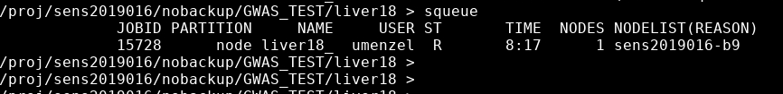

review_gwas running

#### Input files

No input files have to be declared for *review_gwas*. The script reads a number of files created during the previous steps and converts them to the appropiate format. Again, it is important to start the script in the folder containing the output files created by the the scripts run beforehand.

#### Output files

The script *review_gwas* creates the following output files [a star (*) stands for a string which depends on input parameters]:

| File name pattern | Description |
| --- | --- |
| gwas_report.Rmd | Rmarkdown file containing the results |
| gwas_results.RData | Results in zipped (R-) format |
| Filtered_*.RData | Results of filtering |
| *_regression_frame.RData | Auxiliary table |
| *_regression_resid.RData | Auxiliary table |
| *_regression_metric.RData | Auxiliary table |
| *_regression_lmtab.RData | Auxiliary table |
| *_regression_vif.RData | Auxiliary table |
| *_resid_hist.png | Plot: histogram of the residuals |
| *_resid_qq.png | QQ-plot for the residuals |
| *_cook_dist.png | Plot: Cook’s distance |
| *_signif_markers.RData | Auxiliary table |
| *_cojoed_markers.RData | Auxiliary table |
| *_cojoed_orig_markers.RData | Auxiliary table |
| *_clumped_markers.RData | Auxiliary table |
| *_cojo_nearest_genes.RData | Auxiliary table |
| *_clump_nearest_genes.RData | Auxiliary table |
| *_Manhattan.png | Manhattan plot |
| *_snp_density.png | SNP density plot |
| *_QQplot.png | QQ-plot for the $p$-values |
| *_beta_hist.png | Plot: histogram of $\beta$-values |
| *_beta_kernel.png | Kernel density plot of $\beta$-values |
| *_rmd_review_params.RData | Auxiliary table |
| *_signif_markers.xls | Spreadsheet with significant markers |
| *_report.html | Main output of *review_gwas* |
| *_review.log | Main logfile for *review_gwas* |

The most important file, containing the graphical presentation of the results, is *_report.html.  
It can be copied to a local computer and opended with some browser. The HTML file contains a link to an Excel file ( "*_signif_markers.xls" ) containing a list of all genome-wide significant markers. The link works only if the spreadsheet is copied to the same folder as the HTML file. Note that no Excel file is created if too many genome-wide significant markers have been identified, see the description of the *max_xls*-parameter above.

#### Checking accuracy

After running *review_gwas*, it is recommended to check if all parts of the pipeline were executed without failure. Therefore, it is useful to parse all logfiles in the results-folder for errors or warnings. This can be accomplished by using the following Linux commands:

```
fgrep -i error *.log
fgrep -i warning *.log
```

The following warning possibly created in the PLINK-CLUMP step can be ignored: “*No significant - -clump results. Skipping*”. It means that an individual chromosome did not contain any genome-wide significant hit.

A frequently occuring error is runtime limit exceedance, especially for the chromosomes having many markers (e.g. chromosome 2). In that case, the job must be restarted with a higher runtime claim, by scaling up the *minutes*-parameter.

If a more rigorous check is to be done, the script *check_gwas* can be executed, see some details here. This program checks also completeness of the results and considers the dates of the logfiles in order to exclude outdated files.

#### Subprograms

The script *review_gwas* calls the subprogram *review_gwas.R*, which in turn loads several Rmarkdown templates and code chunks (*table_signif.Rmd*, *table_cojoed.Rmd*, *table_clumped.Rmd*, *comparison_plink_clump.Rmd*, *table_unpruned.Rmd*). Additionally, a file *review_functions.R* is loaded, containing some helper-scripts.

#### Examples

In order to run *review_gwas*, you have to change to the folder containing the results of the previously executed scripts. If the identifier was chosen to be “Test” in the regression step, this can be accomplished by typing

```
cd Test
```

The minimal input of *review_gwas* might then be the following (assuming *liver_fat* has been used as a phenotype name in the pipeline):

```
review_gwas --id Test --phenoname liver_fat
```

As mentioned above, *review_gwas* can only take one phenotype at a time.

Sometimes, it might be necessary to repeat the run with increased runtime request, because the job could not be finished timely. The runtime limit can be adjusted by modifying the *minutes* parameter:

```
review_gwas --id Test --phenoname liver_fat --minutes 150
```

(The default runtime, as defined in *~/review_settings.sh*, is 90 minutes.)

Please keep in mind that you can also use the short version of the formal parameters, so that the last command can be replaced by:

```
review_gwas -i Test -pn liver_fat -m 150
```

The *minutes* parameter refers to the runtime for the whole script.

All available command line parameters of *review_gwas* are listed if the command is typed without any arguments. Also, keep in mind that the default options can be changed by modifying the file *~/review_settings.sh*.

### A typical GWAS session

In the following, a complete GWAS run is presented, merely applying a minimal set of the mandatory command line parameters. All other parameters are set to default values by gathering information from the parameter file and from the corresponding settings files.

#### 1. Regression

Jobs can for instance be executed in the folder */proj/sens2019016/GWAS_TEST*. This folder already contains some covariate and phenotype files. (An alternative location would be */proj/sens2019016/nobackup/GWAS_TEST*.)  
Let us assume we are in the above mentioned folder:

```
pwd # /proj/sens2019016/GWAS_TEST
```

An example of a phenotype file is *liver_INT.txt* :

```
ls -l liver_INT.txt
```

The first five rows of this phenotype file can be viewed using the *head* command:

```
head -5 liver_INT.txt
```

which yields the following output:

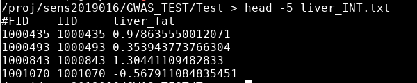

Head of a phenotype file

The file contains a phenotype labelled “liver_fat”. (The *#FID* and *IID* columns are mandatory.) This phenotype file and this phenotype name can be used to run the following regression:

```
run_gwas --id Test --phenofile liver_INT.txt --phenoname liver_fat
```

The phenotype *liver_fat* is a continuous variable. Therefore, a linear regression is carried out. See above for encoding of binary phenotypes. The phenotype file is expected to be located in the current folder (*/proj/sens2019016/GWAS_TEST*), because the *phenofolder* variable is set to the actual folder by the instruction *phenofolder=“.”* in the settings file *~/gwas_settings.sh*. (A dot specifies the actual folder in UNIX/Linux.)

A covariate file name was not given here. It is therefore taken from the parameter file, where *covarfile=“GWAS_covariates_PC40.txt”* is specified. This file contains the covariates “array”, “sex”, “age”, “age_squared”, as well as 40 [Genetic Principal Components](https://biobank.ctsu.ox.ac.uk/showcase/field.cgi?id=22009) calculated by [PCA](https://en.wikipedia.org/wiki/Principal_component_analysis) for 337,466 individuals filtered for Caucasian ethnic background and for absence of relatives in the database. Note that not all covariates included in this file are automatically used in the regression, but only those included in a comma-separated list passed to the variable *covarname*. The *covarname* variable is also defined in the settings file but can also be modified on the command line. It is important to note that the covariate file must reside in the same folder as the phenotype file, i.e. it’s location is determined by the *phenofolder* variable.

If the regression is started as shown above, all human autosomes are included in the GWAS following the specification in *~/gwas_settings.sh*, which reads *chrom=“1-22”*.

We have not assigned any of the parameters *maf*, *mac*. *vif*, *hwe*, *mr2*, *geno*, *mind*, or *minutes* on the command line, so that all values are taken from *~/gwas_settings.sh*. A brief description of these parameters was given above, a detailed description is on the [PLINK website](https://www.cog-genomics.org/plink/1.9/filter).

As already mentioned, the script *run_gwas* creates a folder for each run and stores all output files in this folder. It is convenient to change to this folder in order to follow the progress of the jobs:

```
cd Test
```

(Remember that *Test* was the job-ID chosen.)

The progress of the job can be followed using the *squeue* command:

```
squeue
```

The output of *squeue* might look like that:

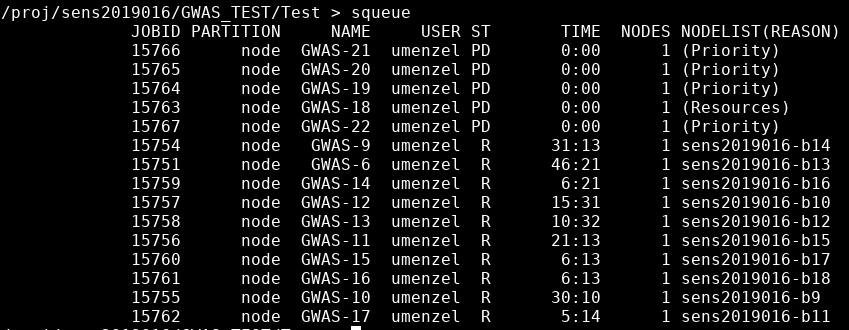

Screenshot of squeue output

There is one job for each chromosome with jobname “GWAS-*XX*”, where “*XX*” stands for the chromosome number. The jobs for the individual chromosomes are submitted simultaneously. However, they might not start immediately because of the lack of available nodes on the server.

The status of the job can be inferred from the status (**ST**) column of the *squeue* command:

- **PD**: job is pending
- **R**: job is running
- **CG**: job is completing

More about technical terms connected with the queue can be found [here](https://www.uppmax.uu.se/support/faq/running-jobs-faq/your-priority-in-the-waiting-job-queue/).

Remember that it is possible to cancel accidentally submitted jobs with the *scancel* command:

```
scancel jobID
```

(The jobID is listed in the **JOBID** column of the *squeue* output.)

You can also cancel all jobs belonging to your user name by typing:

```
scancel -u username
```

At any time, you can look at the logfiles produced using the Linux *more* command, e.g.

```
more Test_gwas.log
```

All logfiles can be listed with

```
ls -l *.log
```

Important parameters are included in the parameter file:

```
more Test_gwas_params.txt
```

However, do *not* change this file under any circumstances (!), because it is used for gathering of information by subsequent scripts.

When the jobs are finished, or even while they are still running, it is recommended to check if the logfiles contain any error messages or warnings:

```
fgrep -i error *.log
fgrep -i warn *.log
```

When the regression was succesful, the main output files can be listed by using:

```
ls -l *.glm.linear
```

or

```
ls -l *.glm.logistic
```

depending on the type of regression made.

A typical file containing regression results looks like that:

```
head -5 Test_gwas_chr1.liver_fat.glm.linear
```

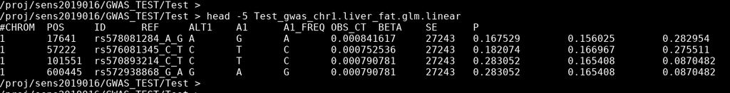

Regression output file

It contains chromosome, position, name, alleles, allele frequencies, $\beta$-values, standard errors, and $p$-values for each marker.

The number of entries in each output file can be counted by executing the command:

```
wc -l Test_gwas*.glm.linear
```

The numbers obtained must agree with the numbers of SNP’s on each chromosome (but keep in mind that the header line is also counted by the above command).

Now, it is possible to look at the results by running *review_gwas*. Alternatively, independent markers can be identified by conducting GCTA-COJO and/or PLINK-CLUMP, see below.

#### 2. GCTA-COJO

In order to find SNP’s in linkage equilibrium (“independent markers”), the program [GCTA-COJO](https://cnsgenomics.com/software/gcta/#COJO) can be applied. It is started on the server using the *run_cojo* script:

```
pwd # /proj/sens2019016/GWAS_TEST/Test
run_cojo --id Test
```

The phenotype name (*phenoname* variable) is not explicitly invoked on the command line. In this case, all phenotypes that have been used in *run_gwas* are considered. In our example, this is only a single phenotype, so that the command

```
run_cojo --id Test  --phenoname liver_fat
```

would start the same job.

If *run_cojo* is started as shown above, it invokes a reduced genotype database (“FTD_rand”) with 10.000 individuals as a [reference dataset](https://cnsgenomics.com/software/gcta/#COJO). In order to apply the same genotype dataset as used in the regression step, the *alt_genoid* entry in *~/cojo_settings.sh* must be removed (or commented out with a hash *#*).

Again, the progress of *run_cojo* can be watched using the *squeue* command. The script submits 25 jobs per phenotype. The individual subprograms have several dependencies, as already described above.

It is recommended to use the *fgrep* commands shown above in order to check if errors occurred or if warning messages have been issued during the run.

After finishing the job, the main output file, with suffix *.jma, should be available:

```
ls -l Test_liver_fat_cojo.jma
```

The file format looks like that:

```
head -5 Test_liver_fat_cojo.jma
```

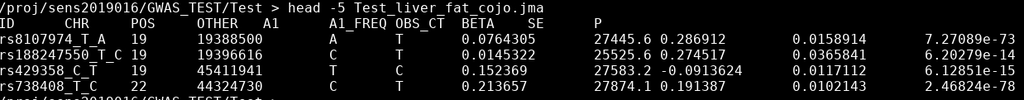

Main COJO output

It is possible to count the number of significant and independent markers with:

```
wc -l Test_liver_fat_cojo.jma
```

More or less as a byproduct, *run_cojo* collects genome-wide significant hits for all chromosomes in a separate text file. This file has always the suffix *gwas_signif.txt*, while the first part of the filename depends on the parameters invoked. It is now easy to count the number of significant (but not independent) markers:

```
wc -l  Test_liver_fat_gwas_signif.txt
```

To have a quick look at the number of significant hits on each chromosome, one can for example type:

```
awk '{print $2}' Test_liver_fat_gwas_signif.txt | uniq -c
```

(The *awk* command just prints the 2nd column of the file.)  
We have 456 hits on chromosome 19 and 206 hits on chromosome 22 for this example.

#### 3. PLINK-CLUMP

An alternative approach to identify markers in linkage equilibrium (“independent markers”) is [PLINK-CLUMP](http://zzz.bwh.harvard.edu/plink/clump.shtml). It can be run by using the *run_clump* program:

```
pwd # /proj/sens2019016/GWAS_TEST/Test
run_clump --id Test
```

Again, the phenotype names are automatically inferred from the parameter file if no phenotype name is invoked explicitly. It would also be possible to specify the phenotype name on the command line:

```
run_clump --id Test --phenoname liver_fat
```

The jobs for the individual chromosomes are started simultaneously and are labelled “CLUMP-*XX*” where "*XX" stands for the chromosome number:

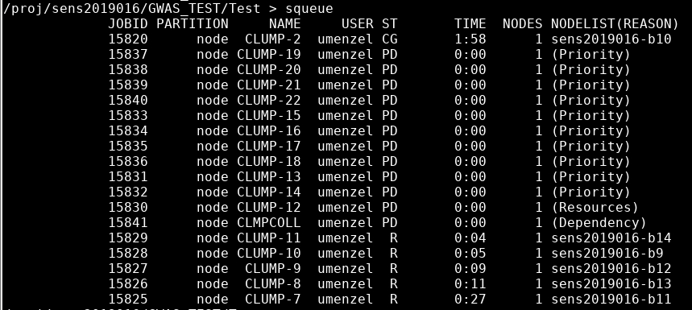

Output of squeue command

If the runtime limit has been exceeded without finishing the job, the job can be restarted with an increased runtime claim:

```
run_clump --id Test --minutes 150
```

In order to check for errors or warnings, inspect all logfiles produced so far:

```
fgrep -i error *.log
fgrep -i warn *.log
```

The following warnings can be ignored:

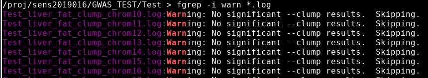

Warnings for run_clump

They merely say that the corresponding chromosome did not include any significant hit (The chromosome number can be inferred from the logfile name).

The main output file of *run_clump* - containing the markers found to be in linkage equilibrium - has the suffix *.jma:

```
ls -l Test_liver_fat_clump.jma
```

The file format is:

```
head -5 Test_liver_fat_clump.jma
```

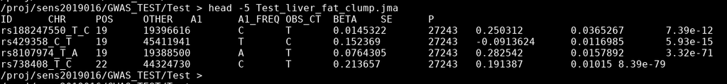

Main CLUMP output

#### 4. Reviewing results

The script *review_gwas* collects all results from the previously submitted programs and creates a file to be opened with a web browser. It has to be started in the folder created by *run_gwas*:

```
pwd # /proj/sens2019016/GWAS_TEST/Test
review_gwas --id Test --phenoname  liver_fat
```

Here, the phenotype name has to be invoked explicitly, because *review_gwas* can only work with a single phenotype at a time.

As before, the *squeue* command can be used to watch the progress of the script. Additionally, you might want to look at the logfile from time to time in order to see how far the script has proceeded:

```
more  Test_liver_fat_review.log
```

(Note that the name of the file again consists of a parameter-dependent part and a fixed part.)

If the file gets bigger and bigger it might be better to list the last (20) rows only:

```
tail -20 Test_liver_fat_review.log
```

The script needs some time to finish because high-resolution graphical output is produced.

The most important output of *review_gwas* is the *.html* file:

```
ls -l Test_liver_fat_report.html
```

Another result is a spreadsheet containing the genome-wide significant markers:

```
ls -l Test_liver_fat_signif_markers.xls
```

(No spreadsheet is created if too many genome-wide significant hits have been identified, the threshold is defined by the *max_xls* parameter, see above.)

In order to inspect the results of the GWAS, copy the *.html* and the *.xls* file to a local computer, and place both files in the same folder. The *.html* file can now be viewed with a browser. Here is an example output.

The output file containing the results of a logistic regression looks slightly different. Here is an example.

#### Summary of the essential commands

Here is a summary of the essential commands submitted to the server:

```
cd /proj/sens2019016/GWAS_TEST
run_gwas --id Test
cd Test
run_cojo --id Test
run_clump --id Test
review_gwas --id Test --phenoname liver_fat
fgrep -i error *.log
fgrep -i warn *.log
ls -l *.html    # main result
ls -l *.xls     # spreadsheet
```

In order to follow up the progress of your jobs, you can use the *squeue* command at any time:

```
squeue
```

If jobs were accidentally submitted, they can be cancelled using:

```
scancel jobid
```

(The jobID is listed in the **JOBID** column of the *squeue* output.)

You can cancel all your jobs with

```
scancel -u username
```

### Concise summary of results

A very concise summary of the results can be obtained using the script *recap_gwas*. The script is fast and does not run in a calculation node, i.e. it starts immediately. However, you have to make sure that the program is started in interactive mode, look here in order to see how to do this.

The script must be started in the folder containing the output files of the previously conducted scripts:

```
pwd # /proj/sens2019016/GWAS_TEST/Test
recap_gwas --id Test
```

The phenotype name is inferred from the parameter file if not explicitly invoked on the command line. Multiple phenotypes can be considered at once. The main output is a spreadsheet containing the most important results of a GWAS session. Content and name of the spreadsheet depend on which programs have been run during the GWAS session.

[output not shown]

The star (*) in the filename description stands for a parameter-dependent string (which consists of the identifier and the phenotype name, separated by an underscore).

If neither GCTA-COJO nor PLINK-CLUMP were run, a list of all genome-wide significant markers is stored in the corresponding spreadsheet. Genome-wide significance is determined by a $p$-value cutoff having a default value of $p_{thres} = 5.0 \cdot 10^{-8}$. The default value is hard-coded in the script. However, the threshold can be changed on command line by using the *- -pval* option , e.g.:

```
recap_gwas --id Test --pval 1e-8
```

The $p$-value is neglected if GCTA-COJO and/or PLINK-CLUMP were run.

If multiple phenotypes were run through GWAS, a subset of phenotype names can be chosen explicitly on the command line, like so:

```
recap_gwas --id Test  --phenoname liver_fat  --pval 1e-8
```

If multiple phenotypes are to be invoked, their names must be separated by a comma:

```
recap_gwas --id Test  --phenoname liver_fat,liver_size  --pval 1e-8
```

Besides the spreadsheet, *recap_gwas* outputs a text file containing the names of the most important files created during the GWAS session. The name of this file ends on *.files.txt. The star (*) in the filename denotes a parameter-dependent string (which consists of the identifier and the phenotype name, separated by an underscore).

### Check GWAS results for errors and warnings

This can be accomplished by using *check_gwas*.

**Example**

```
cd /proj/sens2019016/GWAS_TEST/liver16
check_gwas --id liver16
```

The script writes a comprehensive logifile *gwas_check.log*. The total number of warnings is reported.

### Archiving of projects

GWAS runs can be archived and retrieved using the scripts *archive_gwas* and *retrieve_gwas*, respectively.

The programs must be started from *outside* (!) the results folder. The script *archive_gwas* has only one command line parameter which is the unique identifier used during the whole GWAS session:

```
pwd # /proj/sens2019016/GWAS_TEST
ls -ld Test
archive_gwas --id Test
```

The job is submitted to the batch queue, calling the subprogram *tar_gwas.sh*.  
The whole folder is compressed to a *.tar.gz archive, in the above example to *Test.tar.gz*. A copy of some important files is kept outside the *.tar.gz* archive for fast access. A logfile ("*_archive.log") is written (here: *Test_archive.log*).

A few parameters are defined in the settings file *~/archive_settings.sh* :

| Parameter | Desription | Variable | Default value |
| --- | --- | --- | --- |
| minutes | requested runtime in minutes | same | 10 |
| partition | requested partition (node or core) | same | node |
| delete_folder | delete original folder (0 or 1) | same | 0 (do not delete) |

Note that the original folder is not removed when the default settings apply. However, this can be changed by modifying the *delete_folder* option in the settings file.

For demonstration, let’s move the archive to a different location in the file system:

```
mv -i Test.tar.gz  /proj/sens2019016/nobackup/GWAS_TEST/
```

Here, the original folder can be restored using the *retrieve_gwas* script:

```
cd /proj/sens2019016/nobackup/GWAS_TEST/
retrieve_gwas --id Test
```

The job is sent to the batch queue, calling the subprogram *untar_gwas.sh* with job name “RETRIEVE”.  
The scripts exits with an error message if attempts are made to overwrite an existing folder with the same name.  
In order to gather the necessary *partition* and *minutes* parameters, the *~/archive_settings.sh* file is read.  
The script writes a logfile labelled "*_retrieve.log" (where the star is replaced by the unique identifier)

# Auxiliary scripts

### Diagnostic tests on regression results

#### Overview

The program *gwas_diagnose* performs a detailed analysis of a multiple regression run for a single marker. It conducts a number of diagnostic tests on the variables used during regression and on the residuals resulting therefrom. The regression is conducted in R in order to be able to check if the results obtained by the *PLINK* program can be replicated independently.

It is convenient to start this script in a folder containing GWAS results obtained earlier. This makes it possible for the script to get some information from the parameter file (*_gwas_params.txt). Likewise, a comparison with GWAS results calculated by *PLINK* is made possible.

In a first step, the script extracts the genotype for the given marker using *PLINK2*. The actual analysis is then conducted by the subprogram *gwas_diagnose.R*.

If not invoked on command line, the script reads the name of the covariate file, the covariate names, and the name of the phenotype file from the parameter file ( “*_gwas_params.txt”; created by the *run_gwas* script).

The name of the summary statistics file is also automatically detected, if no alternative name is given on the command line.

Some default parameters are read from “*diagnose_settings.sh*” (which should be located in the home directory).

In order to detect multicollinearity, a (Pearson) correlation matrix and the variance inflation factors for the regressors are calculated.

A comparison of the *PLINK* regression with R-regression results is only possible if the genuine summary statistics file (created by *run_gwas*) is available in the workfolder. If such a comparison is desired, it is suggested not to enter the the name of the covariate file, the covariate name, or the name of the phenotype file ( *- -pheno*, *- -covar*, *- -cname* parameters) on the command line - these parameters are automatically inferred from *_gwas_params.txt, ensuring that both computations use the same input parameters. If no summary statistics file is available, the comparison with the *PLINK* results is dismissed. This opens up for the possibility to run a quick regression for a single marker (if once started in the queue, the script takes 2 to 3 minutes only).

Subsequent to regression, *gwas_diagnose* carries out a number of diagnostic tests on the residuals.  
The diagnostic tests include:

- a calculation of the variance inflation factors for the predictor variables (marker genotype and covariates),
- a calculation of the most important regression metrics, e.g. the estimated standard deviation of the noise term ($\sigma$), the coefficient of determination ($R^2$), and the Akaike information criterion [(AIC)](https://en.wikipedia.org/wiki/Akaike_information_criterion),
- a calculation (in R) of the regression coefficients ($\beta$) for the predictor variables, including their confidence intervals, standard errors, and $p$-values,
- several diagnostic plots for the residuals (QQ-plot, scale-location plot, autocorrelation plot, plot of influential variables),
- a plot of the phenotype versus the marker genotype, in order to illustrate the regression quality,
- an estimation of potential outliers

For detailed information regarding the output created by *gwas_diagnose*, check the example output linked below.

#### Parameters

The program *gwas_diagnose* has the following command line parameters:

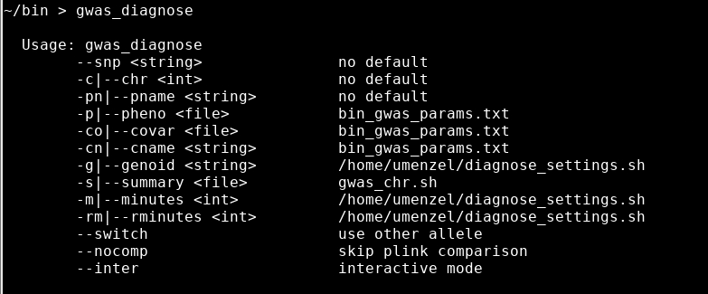

gwas_diagnose options

| Parameter | Description | Variable name | Default value |
| --- | --- | --- | --- |
| snp | Name of the marker to be investigated | marker | no default |
| chr | Chromosome where the marker is located | chrom | no default |
| pname | Phenotype name | phenoname | no default |
| pheno | Phenotype file | phenofile | *_gwas_params.txt |
| covar | Covariates file | covarfile | *_gwas_params.txt |
| cname | Covariate names | covarname | *_gwas_params.txt |
| genoid | Identifier of the input genotype data set | genoid | ~/diagnose_settings.sh |
| summary | Summary statistics file from GWAS session | summaryfile | file name convention |
| minutes | Requested runtine for genotype extraction | minutes | ~/diagnose_settings.sh |
| rminutes | Requested runtine for analysis of residuals | rminutes | ~/diagnose_settings.sh |
| switch | Conduct regression on alternate allele | switch | 0 (use minor allele) |
| nocomp | Skip comparison with PLINK results | nocomp | 0 (compare with PLINK) |
| inter | Run in interactive mode (not in SLURM) | inter | 0 (run in SLURM) |

The 3rd column of the table (“Variable name”) displays the variable names used internally in the scripts and in the settings file *~/diagnose_settings.sh*.

The *- -snp* command line option specifies the **marker** to be investigated. The marker must be included in the genotype database. It is therefore convenient to use some marker listed in the output table of a finished GWAS session (a table in some *review_gwas* output, like this one). Note that the unique marker name has to be invoked, including the characters specifying both alleles. The unique marker name can be inferred from the non-unique name using the script *get_alleles*.

The *- -chr* parameter specifies the **chromosome** the marker is located on. The chromosome number can also be taken from the table in the *review_gwas* output.

The *- -pname* parameter specifies the **name of the phenotype** to be used as a response variable in the regression. This phenotype name must be a column name in the corresponding phenotype file (this is checked by the script). The phenotype file name containing the phenotypes is automatically read from the parameter file *_gwas_params.txt if not explicitely given on the command line. (It is recommended to let the script read the phenotype file name.) The phenotype file must be located in the folder defined by *phenofolder*. (If a dot is entered for phenofolder, the phenotype file must reside in the current folder, i.e. the folder the *gwas_diagnose* is started from.) Phenotype names and phenotype file names can also be looked up in the logfiles or in the parameter file created during a GWAS session.

The **covariates** to use (*- -cname*) and the covariate file (*- -covar*) are automatically inferred from the parameter file (*_gwas_params.txt). The names of the covariates to be included must be column names of the covariate file (also checked by the script). The covariate file must be located in the same folder as the phenotype file (i.e. it must be located in the current folder if a dot was entered for the *phenofolder* variable).

The *genoid* parameter specifies which **genotype dataset** is used as input. Only a few choices are possible, depending on the project you are working with. In general, it should be sufficient to keep the definition which is pre-selected in *~/diagnose_settings.sh*.

If the regression results are to be compared with some *PLINK* results obtained earlier, the script must be started in a folder containing these results. Then, the *gwas_diagnose* uses the **summary file** created by *PLINK* for this comparison. By default, the name of the summary file is guessed (by file name convention, defined in *gwas_chr.sh*). The name of the summary file can be changed using the *- -summary* parameter (not recommended).

The *- -minutes* and the *- -rminutes* parameters specify the requested runtime for the genotype extraction and for the analysis of the residuals, respectively. The default values are specified in *~/diagnose_settings.sh*.

By default, the regression is made on the minor allele (*switch* is set to 0 in *gwas_diagnose.sh*). The regression is conducted on the alternate allele if *- -switch* is set to 1 on the command line.

By default, the script attempts to run a comparison with *PLINK* results. This is ensured by setting *nocomp=0* in *gwas_diagnose.sh*, but can be overwritten on the command line by setting *nocomp* to 1.

If the *- -inter* parameter is not set, the calculations are made by sending the scripts to the **SLURM** (“Simple Linux Utility for Resource Management”) [workload manager](https://slurm.schedmd.com/documentation.html). However, the script can also be run in interactive mode by invoking *- -inter* on the command line. In this case the interactive mode has to be started first, e.g. by using : *interactive -n 16 -t 6:00:00 -A sens2019016*.

Some default parameters are predefined in *diagnose_settings.sh*:

| Parameter | Description | Variable name | Default value |
| --- | --- | --- | --- |
| genoid | genotype file identifier | same | ukb_imp_v3 |
| genofolder | location of the genotype files | same | /proj/sens2019016/GENOTYPES/PGEN |
| phenofolder | phenotype file location | same | current folder |
| minutes | Requested runtine for genotype extraction | same | 10 |
| rminutes | Requested runtine for analysis of residuals | same | 20 |
| partition | partition (node or core) | same | node |

#### Versions

The script *gwas_diagnose_INT* performs a similar analysis as *gwas_diagnose* but puts the “fully adjusted two-stage inverse normal transformation” of the residuals in front of the regression. The transformation is described in this [paper](https://journals.plos.org/plosone/article/file?id=10.1371/journal.pone.0233847&type=printable). The input parameters are the same as for *gwas_diagnose*.

The script *gwas_diagnose_nomarker* runs a regression on the covariates, without a marker involved. The same diagnostic tests are made. This can for instance be helpful if the impact of the marker on the regression is to be assessed. The script uses a limited parameter set compared to *gwas_diagnose*:

| Parameter | Description | Variable name | Default value |
| --- | --- | --- | --- |
| pname | Phenotype name | phenoname | no default |
| pheno | Phenotype file | phenofile | *_gwas_params.txt |
| covar | Covariates file | covarfile | *_gwas_params.txt |
| cname | Covariate names | covarname | *_gwas_params.txt |
| rminutes | Requested runtine for analysis of residuals | rminutes | ~/diagnose_settings.sh |
| inter | Run in interactive mode (not in SLURM) | inter | 0 (run in SLURM) |

The explanations of the parameters are the same as above.

#### Example program calls

1.) Running *gwas_diagnose* with the three mandatory parameters. The unique marker name, including both alleles, must be used. It was ensured beforehand that the marker is on chromosome 5 (by looking at the *review_gwas* output):

```
gwas_diagnose --snp rs767276217_A_G --chr 5 --pname liv5
```

2.) Running *gwas_diagnose* in an interactive session:

```
interactive -n 16 -t 3:00:00 -A sens2019016
cd /castor/project/proj/GWAS_DEV3/liver10
gwas_diagnose --snp rs188247550_T_C  --chr 19 --pheno liver_fat_ext.txt --pname liver_fat_a --inter
```

3.) Running without marker. This runs a regression on the covariates only, followed by the same diagnostic tests:

```
gwas_diagnose_nomarker --pname liver_fat_a
```

4.) Running the diagnostic tests after transformation of the phenotype variable (using the “fully adjusted two-stage inverse normal transformation”):

```
gwas_diagnose_INT --snp rs767276217_A_G --chr 5  --pname liv5
```

```
gwas_diagnose_INT --snp rs767276217_A_G --chr 5  --pname liv2 --switch
```

#### Example output files

An example output file for *gwas_diagnose* is here. An example output file for *gwas_diagnose_nomarker* can be found here. A comparison of the residuals with and without inclusion the the marker is linked here. The comparison was made using the script *compare_residuals* (see below). More example output files can be found in the “MolEpic” domain, for instance in:

- ‘Gold\MolEpi\Personal folders and scripts\Uwe\gwas\sens2019016\DIAGNOSE’ or
- ‘Gold\MolEpi\MolEpic\Imiomics\gwas\sens2019016\DIAGNOSE’

### Comparison of distributions

The script *compare_residuals* can be used to compare two distributions, e.g. the residuals after two different regressions. The residuals must be available in “.RData” format:

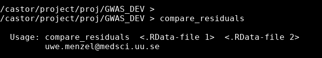

The output includes:

- a comparison of the histograms
- a comparison of the density plots
- a comparison of the QQ-plots
- a comparison of the cumulative distribution plots
- a scatterplot of the residuals against each other

**Example**:

```
compare_residuals resid1.RData  resid2.RData
```

An example output is here.

### Transformation of variables

#### Simple transformations

Simple transformations can be done using the script *transform_phenotypes*. Input parameters are just the phenotype file to transform (in the format required by *PLINK*) and the desired type of transformation. All phenotype columns in the file are transformed (Note that the first two columns are reserved for *IID* and *FID*).

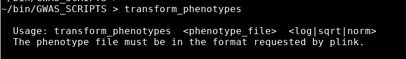

Possible transformation are:

- logarithmic transformation
- square root transformation
- inverse normal transformation ([INT](https://www.ncbi.nlm.nih.gov/pmc/articles/PMC2921808/))

**1.) Example of a logarithmic transformation:**

```
cd /proj/sens2019016/GWAS_TEST
transform_phenotypes liver_fat_pred_c.txt log
```

Output:

- the tranformed file (*liver_fat_pred_c.txt.log_trans*) and
- a plot showing the distributions before and after the transformation:

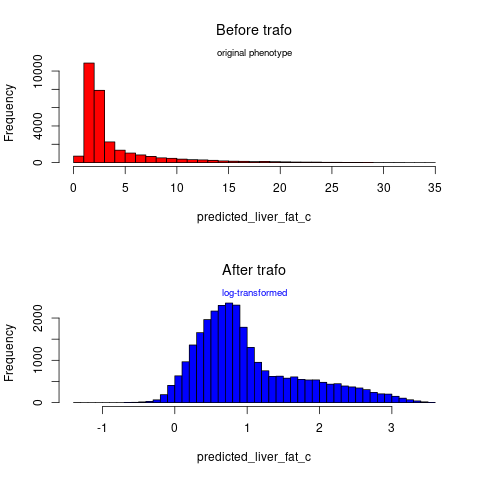

**2.) Example of a square root transformation**:

```
cd /proj/sens2019016/GWAS_TEST
transform_phenotypes liver_fat_pred_c.txt sqrt
```

Output:

- the tranformed file (*liver_fat_pred_c.txt.sqrt_trans*) and
- a plot showing the distributions before and after the transformation:

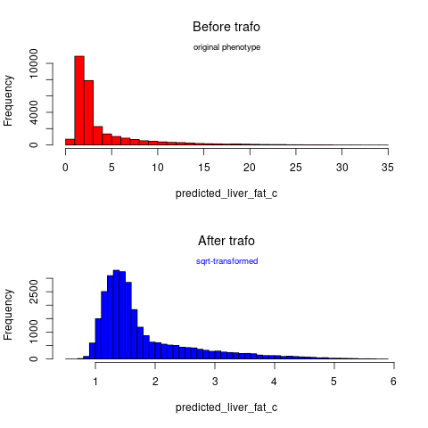

**3.) Example of an inverse normal transformation**:

```
cd /proj/sens2019016/GWAS_TEST
transform_phenotypes liver_fat_pred_c.txt norm
```

Output:

- the tranformed file (*liver_fat_pred_c.txt.norm_trans*) and
- a plot showing the distributions before and after the transformation:

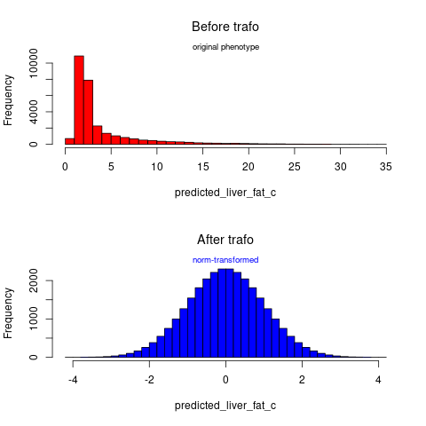

#### Boxcox transformation

The Boxcox transformation can be realised using *transform_phenotypes_boxcox*. Input is the phenotype file, the covariate file, and a string defining the covariates to use in the linear regression. Multiple phenotypes can be transformed simutaneously.

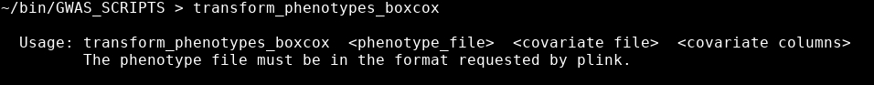

**Example**:

```
cd /proj/sens2019016/GWAS_TEST
covarnames = "PC1,PC2,PC3,PC4,PC5,PC6,PC7,PC8,PC9,PC10,array,sex,age"
transform_phenotypes_boxcox  liver_fat_ext.txt GWAS_covariates.txt ${covarnames}
```

Output:

- the tranformed file (*boxcoxed_liver_fat_ext.txt*)
- a plot showing the log-likelihood vs. $\lambda$
- a plot showing the distributions before and after the transformation

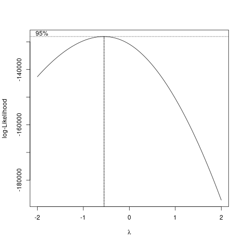

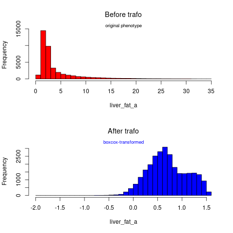

Note that the output might contain fewer lines than the input files because only the intersection of phenotype and covariates can be considered.